# Worked Example: Diamonds

Jonas Wallin

# 1 Diamonds

In this worked example, we’ll use a **beeswarm plot** to compare diamond prices across cut grades. The `diamonds` dataset comes with ggplot2 and contains 53,940 diamonds. It is also used in the course book, [*ggplot2: Elegant Graphics for Data Analysis*](https://ggplot2-book.org/statistical-summaries.html#diamonds-data) by Hadley Wickham, Danielle Navarro, and Thomas Lin Pedersen. See the book’s “Diamonds data” section for an introduction to the dataset.

Let’s load the data and the ggbeeswarm package, which supplies the beeswarm layer.

```r
library(tidyverse)
# install.packages("ggbeeswarm") # if you haven't installed it yet
library(ggbeeswarm)

glimpse(diamonds)
```

```
## Rows: 53,940
## Columns: 10
## $ carat   <dbl> 0.23, 0.21, 0.23, 0.29, 0.31, 0.24, 0.24, 0.26, 0.22, 0.23, 0.…
## $ cut     <ord> Ideal, Premium, Good, Premium, Good, Very Good, Very Good, Ver…
## $ color   <ord> E, E, E, I, J, J, I, H, E, H, J, J, F, J, E, E, I, J, J, J, I,…
## $ clarity <ord> SI2, SI1, VS1, VS2, SI2, VVS2, VVS1, SI1, VS2, VS1, SI1, VS1, …
## $ depth   <dbl> 61.5, 59.8, 56.9, 62.4, 63.3, 62.8, 62.3, 61.9, 65.1, 59.4, 64…
## $ table   <dbl> 55, 61, 65, 58, 58, 57, 57, 55, 61, 61, 55, 56, 61, 54, 62, 58…
## $ price   <int> 326, 326, 327, 334, 335, 336, 336, 337, 337, 338, 339, 340, 34…
## $ x       <dbl> 3.95, 3.89, 4.05, 4.20, 4.34, 3.94, 3.95, 4.07, 3.87, 4.00, 4.…
## $ y       <dbl> 3.98, 3.84, 4.07, 4.23, 4.35, 3.96, 3.98, 4.11, 3.78, 4.05, 4.…
## $ z       <dbl> 2.43, 2.31, 2.31, 2.63, 2.75, 2.48, 2.47, 2.53, 2.49, 2.39, 2.…
```

We will focus on three variables:

- `carat`: the diamond’s weight in carats.
- `cut`: an ordered cut grade, from `Fair` to `Ideal`.
- `price`: the price in US dollars.

## 1.1 Comparing Diamonds of the Same Weight

Large diamonds tend to cost more than small diamonds. To make our comparison more useful, let’s keep only diamonds whose **recorded weight is exactly one carat**. We include every diamond meeting this condition.

```r
one_carat_diamonds <-
  diamonds %>%
  filter(carat == 1)

nrow(one_carat_diamonds)
```

```
## [1] 1558
```

```r
cut_counts <- count(one_carat_diamonds, cut)
cut_counts
```

```
## # A tibble: 5 × 2
##   cut           n
##   <ord>     <int>
## 1 Fair        166
## 2 Good        333
## 3 Very Good   389
## 4 Premium     462
## 5 Ideal       208
```

This leaves 1,558 diamonds, with between 166 and 462 observations per cut grade. Our question is: **How much does price vary among diamonds of the same recorded weight, and how does this differ between cut grades?**

# 2 Beeswarm Plots

In a beeswarm plot, **each dot represents one observation**. Here, the cut grade determines the group on the horizontal axis, and the dot’s height gives the diamond’s price. Dots are moved sideways to separate observations with similar prices. These horizontal offsets have no numerical meaning, and the prices remain unchanged.

The swarm becomes wider where many observations have similar prices. Its width also depends on the number of observations and the spacing settings, so we include the group counts in the axis labels. `size` controls the size of the dots, while `cex` controls the spacing used to arrange them.

Let’s also mark each group’s median using `stat_summary()`. With `fun = median`, this layer calculates one median per cut grade. `shape = 23` gives us a diamond marker, whose interior we make white with `fill = "white"`.

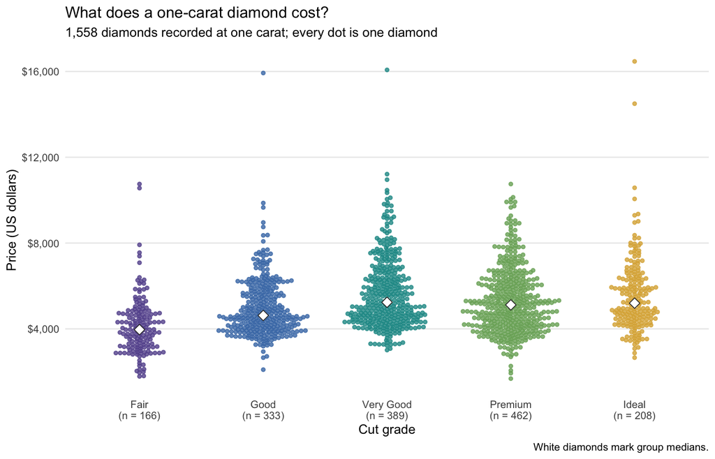

Figure 1: A beeswarm of prices for diamonds recorded at one carat. Each dot represents one diamond, and white markers show group medians.

```r
cut_labels <- paste0(cut_counts$cut, "\n(n = ", cut_counts$n, ")")

ggplot(one_carat_diamonds, aes(cut, price, colour = cut)) +
  geom_beeswarm(size = 1.2, cex = 0.7, alpha = 0.8) +
  stat_summary(
    fun = median, geom = "point", shape = 23,
    size = 3, fill = "white", colour = "grey20"
  ) +
  scale_colour_manual(
    values = c("#65549B", "#477AB4", "#209895", "#79AD67", "#DBAF43"),
    guide = "none"
  ) +
  scale_x_discrete(labels = cut_labels) +
  scale_y_continuous(labels = scales::label_dollar(accuracy = 1)) +
  labs(
    title = "What does a one-carat diamond cost?",
    subtitle = "1,558 diamonds recorded at one carat; every dot is one diamond",
    x = "Cut grade", y = "Price (US dollars)",
    caption = "White diamonds mark group medians."
  ) +
  theme_minimal() +
  theme(
    panel.grid.minor = element_blank(),
    panel.grid.major.x = element_blank()
  )
```

The plot shows substantial price variation within each grade, including a few diamonds costing more than $15,000. The median price is lowest in the `Fair` group, but the medians do not increase at every step from `Fair` to `Ideal`. Even with recorded weight held fixed, diamond colour and clarity still vary. This comparison therefore describes the observed price distributions; it does not isolate the effect of cut grade on price.

## 2.1 Try It Yourself

1. Remove the `stat_summary()` layer. Which comparisons become harder without the median markers?
2. Replace `geom_beeswarm(size = 1.2, cex = 0.7, alpha = 0.8)` with `geom_violin()`. What does the violin summarize, and what information about individual diamonds becomes harder to see?
3. Return to the beeswarm and try different values of `size` and `cex`. How do these choices affect your ability to see individual diamonds and the overall distribution?

```r
# Copy the plot above here and try your modifications.
```

# 3 Source Code

The source code for this document is available at https://github.com/stat-lu/dataviz/blob/main/worked-examples/diamonds.Rmd.